# Overview

Dataset info

| Number of variables | 48 |
| --- | --- |
| Number of observations | 500000 |
| Total Missing (%) | 12.9% |
| Total size in memory | 183.1 MiB |
| Average record size in memory | 384.0 B |

Variables types

| Numeric | 20 |
| --- | --- |
| Categorical | 15 |
| Boolean | 2 |
| Date | 0 |
| Text (Unique) | 3 |
| Rejected | 8 |
| Unsupported | 0 |

Warnings

- `W_BASE_CD` has constant value 100100 Rejected
- `W_CAUSAL_PART_NO` has a high cardinality: 23108 distinct values Warning
- `W_CFC_AMT` is highly skewed (γ1 = 20.804) Skewed
- `W_CFC_AMT` has 342037 / 68.4% zeros Zeros
- `W_CFC_COMPANY_CD` has 38203 / 7.6% missing values Missing
- `W_CFC_COMPANY_CD` has a high cardinality: 415 distinct values Warning
- `W_CFC_RATE` has 342035 / 68.4% zeros Zeros
- `W_DIST_CD` has a high cardinality: 485 distinct values Warning
- `W_DIST_COUNTRY_CD` has a high cardinality: 93 distinct values Warning
- `W_DIST_ISSUE_NO` has a high cardinality: 351229 distinct values Warning
- `W_DIV1` has 273744 / 54.7% missing values Missing
- `W_DIV2` has 210679 / 42.1% zeros Zeros
- `W_DIV3` has 214382 / 42.9% missing values Missing
- `W_DTC_1` has 500000 / 100.0% missing values Missing
- `W_DTC_1` has constant value Rejected
- `W_DTC_2` has 500000 / 100.0% missing values Missing
- `W_DTC_2` has constant value Rejected
- `W_FCOK` has a high cardinality: 467 distinct values Warning
- `W_FIELD_CLAIM_DIV` has 50277 / 10.1% zeros Zeros
- `W_FIXED_DIV` has constant value 1 Rejected
- `W_LABOR_AMT` has 20077 / 4.0% zeros Zeros
- `W_LABOR_HOUR` has 19929 / 4.0% zeros Zeros
- `W_MILEAGE` has 9923 / 2.0% zeros Zeros
- `W_OPERATION_CD` has 214917 / 43.0% missing values Missing
- `W_OPERATION_CD` has a high cardinality: 1988 distinct values Warning
- `W_PARTS_AMT` has 108944 / 21.8% zeros Zeros
- `W_PROD_MODEL_CD` has a high cardinality: 4040 distinct values Warning
- `W_SALES_TO_FAILURE` has 22441 / 4.5% zeros Zeros
- `W_SB_NO` has 500000 / 100.0% missing values Missing
- `W_SB_NO` has constant value Rejected
- `W_SHIPPING_AMT` is highly skewed (γ1 = 23.792) Skewed
- `W_SHIPPING_AMT` has 256648 / 51.3% zeros Zeros
- `W_SHOP_CD` has 286728 / 57.3% missing values Missing
- `W_SRC_DIV` has constant value 1 Rejected
- `W_SUBLET_AMT` is highly skewed (γ1 = 39.97) Skewed
- `W_SUBLET_AMT` has 466134 / 93.2% zeros Zeros
- `W_SUBLET_HOUR` has constant value 0 Rejected
- `W_TOTAL_AMT` is highly correlated with `W_PARTS_AMT` (ρ = 0.90031) Rejected
- `W_TROUBLE_CC` has 285618 / 57.1% missing values Missing
- `W_TROUBLE_CP` has a high cardinality: 256 distinct values Warning
- `W_TROUBLE_DF` has a high cardinality: 287 distinct values Warning
- `W_TROUBLE_MP` has 285618 / 57.1% missing values Missing
- `W_VIN` has a high cardinality: 433661 distinct values Warning

# Variables

W_BASE_CD  
Constant

*This variable is constant and should be ignored for analysis*

| Constant value | 100100 |
| --- | --- |

W_CAUSAL_PART_NO  
Categorical

| Distinct count | 23108 |
| --- | --- |
| Unique (%) | 4.6% |
| Missing (%) | 0.0% |
| Missing (n) | 0 |

| 85104-82K13-RX0 | 53554 |
| --- | --- |
| 41930-71810-RX0 | 34446 |
| 73930-83E00-RX0 | 23803 |
| Other values (23105) | 388197 |

Toggle details

| Value | Count | Frequency (%) |  |
| --- | --- | --- | --- |
| 85104-82K13-RX0 | 53554 | 10.7% |  |
| 41930-71810-RX0 | 34446 | 6.9% |  |
| 73930-83E00-RX0 | 23803 | 4.8% |  |
| 28100-54830-RX0 | 22725 | 4.5% |  |
| 85107-VDXXX | 17876 | 3.6% |  |
| 28100-57830-RX0 | 13219 | 2.6% |  |
| 59000-01820-RX0 | 7024 | 1.4% |  |
| 89360-79J00-RX0 | 6664 | 1.3% |  |
| 61400-44820-RX0 | 6298 | 1.3% |  |
| 17512-61800-RX0 | 6090 | 1.2% |  |
| Other values (23098) | 308301 | 61.7% |  |

W_CFC_AMT  
Numeric

| Distinct count | 17438 |
| --- | --- |
| Unique (%) | 3.5% |
| Missing (%) | 0.0% |
| Missing (n) | 0 |
| Infinite (%) | 0.0% |
| Infinite (n) | 0 |

| Mean | 1810.8 |
| --- | --- |
| Minimum | 0 |
| Maximum | 491806 |
| Zeros (%) | 68.4% |

Toggle details

**Statistics**

Quantile statistics

| Minimum | 0 |
| --- | --- |
| 5-th percentile | 0 |
| Q1 | 0 |
| Median | 0 |
| Q3 | 669 |
| 95-th percentile | 7330 |
| Maximum | 491806 |
| Range | 491806 |
| Interquartile range | 669 |

Descriptive statistics

| Standard deviation | 9267.7 |
| --- | --- |
| Coef of variation | 5.1179 |
| Kurtosis | 716.99 |
| Mean | 1810.8 |
| MAD | 2744.5 |
| Skewness | 20.804 |
| Sum | 905416648 |
| Variance | 85891000 |
| Memory size | 3.8 MiB |

**Histogram**

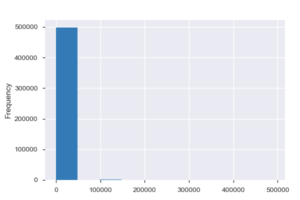

**Common Values**

| Value | Count | Frequency (%) |  |
| --- | --- | --- | --- |
| 0 | 342037 | 68.4% |  |
| 5450 | 1564 | 0.3% |  |
| 999 | 1503 | 0.3% |  |
| 5003 | 1412 | 0.3% |  |
| 6299 | 1092 | 0.2% |  |
| 2478 | 1060 | 0.2% |  |
| 134 | 853 | 0.2% |  |
| 1596 | 841 | 0.2% |  |
| 5412 | 805 | 0.2% |  |
| 3372 | 753 | 0.2% |  |
| Other values (17428) | 148080 | 29.6% |  |

**Extreme Values**

Minimum 5 values

| Value | Count | Frequency (%) |  |
| --- | --- | --- | --- |
| 0 | 342037 | 68.4% |  |
| 1 | 4 | 0.0% |  |
| 2 | 1 | 0.0% |  |
| 3 | 3 | 0.0% |  |
| 4 | 13 | 0.0% |  |

Maximum 5 values

| Value | Count | Frequency (%) |  |
| --- | --- | --- | --- |
| 468629 | 1 | 0.0% |  |
| 471783 | 1 | 0.0% |  |
| 474791 | 1 | 0.0% |  |
| 487176 | 1 | 0.0% |  |
| 491806 | 1 | 0.0% |  |

W_CFC_COMPANY_CD  
Categorical

| Distinct count | 415 |
| --- | --- |
| Unique (%) | 0.1% |
| Missing (%) | 7.6% |
| Missing (n) | 38203 |

| P58X | 170866 |
| --- | --- |
| P583 | 26283 |
| 3343 | 21086 |
| Other values (411) | 243562 |
| (Missing) | 38203 |

Toggle details

| Value | Count | Frequency (%) |  |
| --- | --- | --- | --- |
| P58X | 170866 | 34.2% |  |
| P583 | 26283 | 5.3% |  |
| 3343 | 21086 | 4.2% |  |
| 3430 | 19663 | 3.9% |  |
| 3111 | 14151 | 2.8% |  |
| 3149 | 13467 | 2.7% |  |
| 3039 | 10456 | 2.1% |  |
| 3059 | 8792 | 1.8% |  |
| 3438 | 8265 | 1.7% |  |
| 3223 | 7528 | 1.5% |  |
| Other values (404) | 161240 | 32.2% |  |
| (Missing) | 38203 | 7.6% |  |

W_CFC_RATE  
Numeric

| Distinct count | 78 |
| --- | --- |
| Unique (%) | 0.0% |
| Missing (%) | 0.0% |
| Missing (n) | 0 |
| Infinite (%) | 0.0% |
| Infinite (n) | 0 |

| Mean | 13.035 |
| --- | --- |
| Minimum | 0 |
| Maximum | 100 |
| Zeros (%) | 68.4% |

Toggle details

**Statistics**

Quantile statistics

| Minimum | 0 |
| --- | --- |
| 5-th percentile | 0 |
| Q1 | 0 |
| Median | 0 |
| Q3 | 10 |
| 95-th percentile | 87 |
| Maximum | 100 |
| Range | 100 |
| Interquartile range | 10 |

Descriptive statistics

| Standard deviation | 25.25 |
| --- | --- |
| Coef of variation | 1.9371 |
| Kurtosis | 2.8057 |
| Mean | 13.035 |
| MAD | 19.04 |
| Skewness | 1.9549 |
| Sum | 6517447 |
| Variance | 637.56 |
| Memory size | 3.8 MiB |

**Histogram**

[figure not shown]

**Common Values**

| Value | Count | Frequency (%) |  |
| --- | --- | --- | --- |
| 0 | 342035 | 68.4% |  |
| 50 | 32781 | 6.6% |  |
| 90 | 18503 | 3.7% |  |
| 5 | 10148 | 2.0% |  |
| 3 | 8855 | 1.8% |  |
| 30 | 7029 | 1.4% |  |
| 10 | 6654 | 1.3% |  |
| 100 | 5579 | 1.1% |  |
| 6 | 5555 | 1.1% |  |
| 38 | 4128 | 0.8% |  |
| Other values (68) | 58733 | 11.7% |  |

**Extreme Values**

Minimum 5 values

| Value | Count | Frequency (%) |  |
| --- | --- | --- | --- |
| 0 | 342035 | 68.4% |  |
| 1 | 1730 | 0.3% |  |
| 2 | 1492 | 0.3% |  |
| 3 | 8855 | 1.8% |  |
| 4 | 1575 | 0.3% |  |

Maximum 5 values

| Value | Count | Frequency (%) |  |
| --- | --- | --- | --- |
| 92 | 738 | 0.1% |  |
| 95 | 8 | 0.0% |  |
| 97 | 1 | 0.0% |  |
| 98 | 64 | 0.0% |  |
| 100 | 5579 | 1.1% |  |

W_CRT_TIME_STAMP  
Categorical, Unique

| First 3 values |
| --- |
| 17-06-19 18:07:49.106910000 |
| 17-06-19 18:13:50.993701000 |
| 17-06-19 18:26:20.807084000 |

| Last 3 values |
| --- |
| 17-06-19 18:00:21.796828000 |
| 17-06-19 18:06:42.973312000 |
| 17-06-19 17:47:31.519825000 |

Toggle details

First 10 values

| Value | Count | Frequency (%) |  |
| --- | --- | --- | --- |
| 17-06-19 17:45:34.247188000 | 1 | 0.0% |  |
| 17-06-19 17:45:34.252695000 | 1 | 0.0% |  |
| 17-06-19 17:45:34.255479000 | 1 | 0.0% |  |
| 17-06-19 17:45:34.258218000 | 1 | 0.0% |  |
| 17-06-19 17:45:34.260173000 | 1 | 0.0% |  |

Last 10 values

| Value | Count | Frequency (%) |  |
| --- | --- | --- | --- |
| 17-06-19 18:51:21.877555000 | 1 | 0.0% |  |
| 17-06-19 18:51:21.886310000 | 1 | 0.0% |  |
| 17-06-19 18:51:21.895029000 | 1 | 0.0% |  |
| 17-06-19 18:51:21.896869000 | 1 | 0.0% |  |
| 17-06-19 18:51:21.898617000 | 1 | 0.0% |  |

W_DIST_CD  
Categorical

| Distinct count | 485 |
| --- | --- |
| Unique (%) | 0.1% |
| Missing (%) | 0.0% |
| Missing (n) | 0 |

| 1013B | 47219 |
| --- | --- |
| 5106B | 46430 |
| 1013A | 22132 |
| Other values (482) | 384219 |

Toggle details

| Value | Count | Frequency (%) |  |
| --- | --- | --- | --- |
| 1013B | 47219 | 9.4% |  |
| 5106B | 46430 | 9.3% |  |
| 1013A | 22132 | 4.4% |  |
| 3964B | 13493 | 2.7% |  |
| 1050B | 11759 | 2.4% |  |
| 6473B | 11275 | 2.3% |  |
| 1945B | 10904 | 2.2% |  |
| 3091B | 9063 | 1.8% |  |
| 50311 | 6443 | 1.3% |  |
| 30101 | 6213 | 1.2% |  |
| Other values (475) | 315069 | 63.0% |  |

W_DIST_COUNTRY_CD  
Categorical

| Distinct count | 93 |
| --- | --- |
| Unique (%) | 0.0% |
| Missing (%) | 0.0% |
| Missing (n) | 0 |

| JP | 214382 |
| --- | --- |
| US | 72802 |
| HU | 46739 |
| Other values (90) | 166077 |

Toggle details

| Value | Count | Frequency (%) |  |
| --- | --- | --- | --- |
| JP | 214382 | 42.9% |  |
| US | 72802 | 14.6% |  |
| HU | 46739 | 9.3% |  |
| DE | 19196 | 3.8% |  |
| AU | 16452 | 3.3% |  |
| CA | 13807 | 2.8% |  |
| GB | 12863 | 2.6% |  |
| MX | 11497 | 2.3% |  |
| IT | 9734 | 1.9% |  |
| FR | 6796 | 1.4% |  |
| Other values (83) | 75732 | 15.1% |  |

W_DIST_ISSUE_NO  
Categorical

| Distinct count | 351229 |
| --- | --- |
| Unique (%) | 70.2% |
| Missing (%) | 0.1% |
| Missing (n) | 686 |

| H000 | 555 |
| --- | --- |
| 15010002 | 32 |
| 15040003 | 30 |
| Other values (351225) | 498697 |
| (Missing) | 686 |

Toggle details

| Value | Count | Frequency (%) |  |
| --- | --- | --- | --- |
| H000 | 555 | 0.1% |  |
| 15010002 | 32 | 0.0% |  |
| 15040003 | 30 | 0.0% |  |
| 15050001 | 30 | 0.0% |  |
| 15040006 | 30 | 0.0% |  |
| 15010001 | 30 | 0.0% |  |
| 15010010 | 30 | 0.0% |  |
| 15040005 | 30 | 0.0% |  |
| 15040009 | 30 | 0.0% |  |
| 15020001 | 29 | 0.0% |  |
| Other values (351218) | 498488 | 99.7% |  |
| (Missing) | 686 | 0.1% |  |

W_DIV1  
Categorical

| Distinct count | 14 |
| --- | --- |
| Unique (%) | 0.0% |
| Missing (%) | 54.7% |
| Missing (n) | 273744 |

| 1 | 98323 |
| --- | --- |
| 4 | 89383 |
| 4 | 11798 |
| Other values (10) | 26752 |
| (Missing) | 273744 |

Toggle details

| Value | Count | Frequency (%) |  |
| --- | --- | --- | --- |
| 1 | 98323 | 19.7% |  |
| 4 | 89383 | 17.9% |  |
| 4 | 11798 | 2.4% |  |
| 2 | 9212 | 1.8% |  |
| B | 6922 | 1.4% |  |
| A | 4952 | 1.0% |  |
| 1 | 4359 | 0.9% |  |
| 0 | 787 | 0.2% |  |
| 9 | 290 | 0.1% |  |
| 2 | 221 | 0.0% |  |
| Other values (3) | 9 | 0.0% |  |
| (Missing) | 273744 | 54.7% |  |

W_DIV2  
Numeric

| Distinct count | 6 |
| --- | --- |
| Unique (%) | 0.0% |
| Missing (%) | 0.0% |
| Missing (n) | 0 |
| Infinite (%) | 0.0% |
| Infinite (n) | 0 |

| Mean | 1.1762 |
| --- | --- |
| Minimum | 0 |
| Maximum | 6 |
| Zeros (%) | 42.1% |

Toggle details

**Statistics**

Quantile statistics

| Minimum | 0 |
| --- | --- |
| 5-th percentile | 0 |
| Q1 | 0 |
| Median | 2 |
| Q3 | 2 |
| 95-th percentile | 2 |
| Maximum | 6 |
| Range | 6 |
| Interquartile range | 2 |

Descriptive statistics

| Standard deviation | 1.0268 |
| --- | --- |
| Coef of variation | 0.87296 |
| Kurtosis | -1.107 |
| Mean | 1.1762 |
| MAD | 0.99127 |
| Skewness | -0.072553 |
| Sum | 588123 |
| Variance | 1.0544 |
| Memory size | 3.8 MiB |

**Histogram**

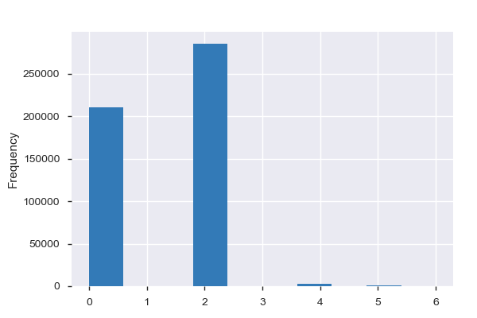

**Common Values**

| Value | Count | Frequency (%) |  |
| --- | --- | --- | --- |
| 2 | 285192 | 57.0% |  |
| 0 | 210679 | 42.1% |  |
| 4 | 3055 | 0.6% |  |
| 5 | 720 | 0.1% |  |
| 6 | 313 | 0.1% |  |
| 1 | 41 | 0.0% |  |

**Extreme Values**

Minimum 5 values

| Value | Count | Frequency (%) |  |
| --- | --- | --- | --- |
| 0 | 210679 | 42.1% |  |
| 1 | 41 | 0.0% |  |
| 2 | 285192 | 57.0% |  |
| 4 | 3055 | 0.6% |  |
| 5 | 720 | 0.1% |  |

Maximum 5 values

| Value | Count | Frequency (%) |  |
| --- | --- | --- | --- |
| 1 | 41 | 0.0% |  |
| 2 | 285192 | 57.0% |  |
| 4 | 3055 | 0.6% |  |
| 5 | 720 | 0.1% |  |
| 6 | 313 | 0.1% |  |

W_DIV3  
Categorical

| Distinct count | 5 |
| --- | --- |
| Unique (%) | 0.0% |
| Missing (%) | 42.9% |
| Missing (n) | 214382 |

| 0 | 241171 |
| --- | --- |
| T | 35869 |
| X | 6732 |
| (Missing) | 214382 |

Toggle details

| Value | Count | Frequency (%) |  |
| --- | --- | --- | --- |
| 0 | 241171 | 48.2% |  |
| T | 35869 | 7.2% |  |
| X | 6732 | 1.3% |  |
| P | 1846 | 0.4% |  |
| (Missing) | 214382 | 42.9% |  |

W_DMEX_DIV  
Boolean

| Distinct count | 2 |
| --- | --- |
| Unique (%) | 0.0% |
| Missing (%) | 0.0% |
| Missing (n) | 0 |

| Mean | 0.57124 |
| --- | --- |

| 1 | 285618 |
| --- | --- |
| 0 | 214382 |

Toggle details

| Value | Count | Frequency (%) |  |
| --- | --- | --- | --- |
| 1 | 285618 | 57.1% |  |
| 0 | 214382 | 42.9% |  |

W_DTC_1  
Constant

*This variable is constant and should be ignored for analysis*

| Constant value |  |
| --- | --- |

W_DTC_2  
Constant

*This variable is constant and should be ignored for analysis*

| Constant value |  |
| --- | --- |

W_FAILURE_DATE  
Numeric

| Distinct count | 688 |
| --- | --- |
| Unique (%) | 0.1% |
| Missing (%) | 0.0% |
| Missing (n) | 0 |
| Infinite (%) | 0.0% |
| Infinite (n) | 0 |

| Mean | 20149000 |
| --- | --- |
| Minimum | 20041028 |
| Maximum | 20151120 |
| Zeros (%) | 0.0% |

Toggle details

**Statistics**

Quantile statistics

| Minimum | 20041028 |
| --- | --- |
| 5-th percentile | 20141000 |
| Q1 | 20150000 |
| Median | 20150000 |
| Q3 | 20151000 |
| 95-th percentile | 20151000 |
| Maximum | 20151120 |
| Range | 110092 |
| Interquartile range | 316 |

Descriptive statistics

| Standard deviation | 3025.9 |
| --- | --- |
| Coef of variation | 0.00015018 |
| Kurtosis | 49.458 |
| Mean | 20149000 |
| MAD | 1885.5 |
| Skewness | -3.6699 |
| Sum | 10074669037838 |
| Variance | 9156300 |
| Memory size | 3.8 MiB |

**Histogram**

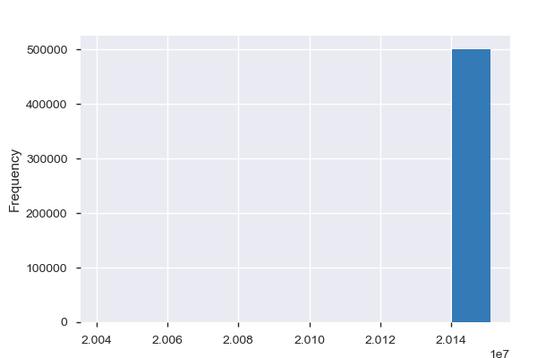

**Common Values**

| Value | Count | Frequency (%) |  |
| --- | --- | --- | --- |
| 20150129 | 4072 | 0.8% |  |
| 20150205 | 4047 | 0.8% |  |
| 20150130 | 3945 | 0.8% |  |
| 20150206 | 3848 | 0.8% |  |
| 20150401 | 3668 | 0.7% |  |
| 20150126 | 3599 | 0.7% |  |
| 20150227 | 3583 | 0.7% |  |
| 20150226 | 3553 | 0.7% |  |
| 20150210 | 3546 | 0.7% |  |
| 20150212 | 3542 | 0.7% |  |
| Other values (678) | 462597 | 92.5% |  |

**Extreme Values**

Minimum 5 values

| Value | Count | Frequency (%) |  |
| --- | --- | --- | --- |
| 20041028 | 2 | 0.0% |  |
| 20041102 | 1 | 0.0% |  |
| 20041110 | 1 | 0.0% |  |
| 20041126 | 1 | 0.0% |  |
| 20041214 | 2 | 0.0% |  |

Maximum 5 values

| Value | Count | Frequency (%) |  |
| --- | --- | --- | --- |
| 20151116 | 981 | 0.2% |  |
| 20151117 | 675 | 0.1% |  |
| 20151118 | 547 | 0.1% |  |
| 20151119 | 923 | 0.2% |  |
| 20151120 | 430 | 0.1% |  |

W_FCOK  
Categorical

| Distinct count | 467 |
| --- | --- |
| Unique (%) | 0.1% |
| Missing (%) | 0.0% |
| Missing (n) | 0 |

| 20131001 | 5163 |
| --- | --- |
| 20130901 | 5114 |
| 20130901 | 5022 |
| Other values (464) | 484701 |

Toggle details

| Value | Count | Frequency (%) |  |
| --- | --- | --- | --- |
| 20131001 | 5163 | 1.0% |  |
| 20130901 | 5114 | 1.0% |  |
| 20130901 | 5022 | 1.0% |  |
| 20150201 | 4871 | 1.0% |  |
| 20131001 | 4862 | 1.0% |  |
| 20120501 | 4213 | 0.8% |  |
| 20120401 | 4189 | 0.8% |  |
| 20131101 | 4033 | 0.8% |  |
| 20120301 | 4015 | 0.8% |  |
| 20131101 | 4005 | 0.8% |  |
| Other values (457) | 454513 | 90.9% |  |

W_FC_TO_FAILURE  
Numeric

| Distinct count | 248 |
| --- | --- |
| Unique (%) | 0.0% |
| Missing (%) | 0.0% |
| Missing (n) | 0 |
| Infinite (%) | 0.0% |
| Infinite (n) | 0 |

| Mean | 51.523 |
| --- | --- |
| Minimum | -5 |
| Maximum | 999 |
| Zeros (%) | 0.2% |

Toggle details

**Statistics**

Quantile statistics

| Minimum | -5 |
| --- | --- |
| 5-th percentile | 4 |
| Q1 | 20 |
| Median | 40 |
| Q3 | 69 |
| 95-th percentile | 140 |
| Maximum | 999 |
| Range | 1004 |
| Interquartile range | 49 |

Descriptive statistics

| Standard deviation | 58.657 |
| --- | --- |
| Coef of variation | 1.1385 |
| Kurtosis | 150.62 |
| Mean | 51.523 |
| MAD | 32.32 |
| Skewness | 9.7066 |
| Sum | 25761626 |
| Variance | 3440.6 |
| Memory size | 3.8 MiB |

**Histogram**

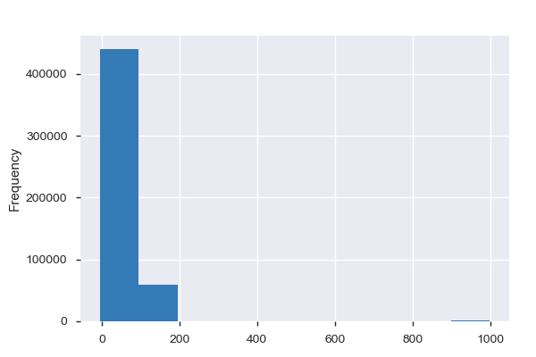

**Common Values**

| Value | Count | Frequency (%) |  |
| --- | --- | --- | --- |
| 36 | 15261 | 3.1% |  |
| 37 | 9098 | 1.8% |  |
| 3 | 8832 | 1.8% |  |
| 14 | 8707 | 1.7% |  |
| 60 | 8655 | 1.7% |  |
| 13 | 8442 | 1.7% |  |
| 15 | 7939 | 1.6% |  |
| 2 | 7564 | 1.5% |  |
| 24 | 7508 | 1.5% |  |
| 16 | 7378 | 1.5% |  |
| Other values (238) | 410616 | 82.1% |  |

**Extreme Values**

Minimum 5 values

| Value | Count | Frequency (%) |  |
| --- | --- | --- | --- |
| -5 | 1 | 0.0% |  |
| -4 | 1 | 0.0% |  |
| 0 | 964 | 0.2% |  |
| 1 | 4716 | 0.9% |  |
| 2 | 7564 | 1.5% |  |

Maximum 5 values

| Value | Count | Frequency (%) |  |
| --- | --- | --- | --- |
| 270 | 1 | 0.0% |  |
| 272 | 1 | 0.0% |  |
| 292 | 1 | 0.0% |  |
| 325 | 1 | 0.0% |  |
| 999 | 1124 | 0.2% |  |

W_FIELD_CLAIM_DIV  
Numeric

| Distinct count | 3 |
| --- | --- |
| Unique (%) | 0.0% |
| Missing (%) | 0.0% |
| Missing (n) | 0 |
| Infinite (%) | 0.0% |
| Infinite (n) | 0 |

| Mean | 1.3896 |
| --- | --- |
| Minimum | 0 |
| Maximum | 2 |
| Zeros (%) | 10.1% |

Toggle details

**Statistics**

Quantile statistics

| Minimum | 0 |
| --- | --- |
| 5-th percentile | 0 |
| Q1 | 1 |
| Median | 1 |
| Q3 | 2 |
| 95-th percentile | 2 |
| Maximum | 2 |
| Range | 2 |
| Interquartile range | 1 |

Descriptive statistics

| Standard deviation | 0.66251 |
| --- | --- |
| Coef of variation | 0.47676 |
| Kurtosis | -0.65165 |
| Mean | 1.3896 |
| MAD | 0.59838 |
| Skewness | -0.62775 |
| Sum | 694798 |
| Variance | 0.43892 |
| Memory size | 3.8 MiB |

**Histogram**

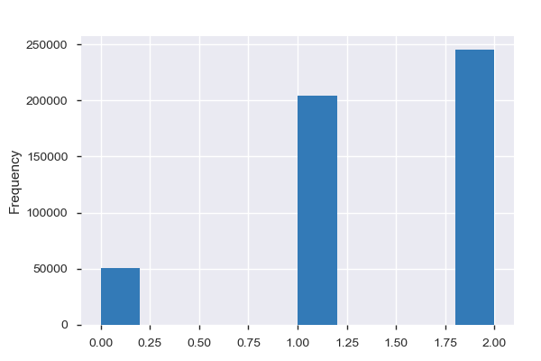

**Common Values**

| Value | Count | Frequency (%) |  |
| --- | --- | --- | --- |
| 2 | 245075 | 49.0% |  |
| 1 | 204648 | 40.9% |  |
| 0 | 50277 | 10.1% |  |

**Extreme Values**

Minimum 5 values

| Value | Count | Frequency (%) |  |
| --- | --- | --- | --- |
| 0 | 50277 | 10.1% |  |
| 1 | 204648 | 40.9% |  |
| 2 | 245075 | 49.0% |  |

Maximum 5 values

| Value | Count | Frequency (%) |  |
| --- | --- | --- | --- |
| 0 | 50277 | 10.1% |  |
| 1 | 204648 | 40.9% |  |
| 2 | 245075 | 49.0% |  |

W_FIXED_DIV  
Constant

*This variable is constant and should be ignored for analysis*

| Constant value | 1 |
| --- | --- |

W_KEY  
Categorical, Unique

| First 3 values |
| --- |
| WRDEJP201504B000825 |
| WRPRJP201502B000258 |
| WRJPJP201502B024771 |

| Last 3 values |
| --- |
| WRJPJP201511B005819 |
| WRAUJP201502B001410 |
| WRJPJP201505B013344 |

Toggle details

First 10 values

| Value | Count | Frequency (%) |  |
| --- | --- | --- | --- |
| WRAEJP201501B000001 | 1 | 0.0% |  |
| WRAEJP201501B000002 | 1 | 0.0% |  |
| WRAEJP201501B000003 | 1 | 0.0% |  |
| WRAEJP201501B000004 | 1 | 0.0% |  |
| WRAEJP201501B000005 | 1 | 0.0% |  |

Last 10 values

| Value | Count | Frequency (%) |  |
| --- | --- | --- | --- |
| WRZAJP201511A000045 | 1 | 0.0% |  |
| WRZAJP201511A000046 | 1 | 0.0% |  |
| WRZAJP201511A000047 | 1 | 0.0% |  |
| WRZAJP201511A000048 | 1 | 0.0% |  |
| WRZAJP201511A000050 | 1 | 0.0% |  |

W_LABOR_AMT  
Numeric

| Distinct count | 6349 |
| --- | --- |
| Unique (%) | 1.3% |
| Missing (%) | 0.0% |
| Missing (n) | 0 |
| Infinite (%) | 0.0% |
| Infinite (n) | 0 |

| Mean | 5680.1 |
| --- | --- |
| Minimum | -79200 |
| Maximum | 534727 |
| Zeros (%) | 4.0% |

Toggle details

**Statistics**

Quantile statistics

| Minimum | -79200 |
| --- | --- |
| 5-th percentile | 387 |
| Q1 | 2400 |
| Median | 3120 |
| Q3 | 6976 |
| 95-th percentile | 16800 |
| Maximum | 534727 |
| Range | 613927 |
| Interquartile range | 4576 |

Descriptive statistics

| Standard deviation | 7469 |
| --- | --- |
| Coef of variation | 1.3149 |
| Kurtosis | 130.72 |
| Mean | 5680.1 |
| MAD | 4147.1 |
| Skewness | 7.1026 |
| Sum | 2840028738 |
| Variance | 55786000 |
| Memory size | 3.8 MiB |

**Histogram**

[figure not shown]

**Common Values**

| Value | Count | Frequency (%) |  |
| --- | --- | --- | --- |
| 3000 | 56415 | 11.3% |  |
| 1800 | 24269 | 4.9% |  |
| 0 | 20077 | 4.0% |  |
| 2496 | 16297 | 3.3% |  |
| 3100 | 11577 | 2.3% |  |
| 4200 | 10473 | 2.1% |  |
| 8752 | 10312 | 2.1% |  |
| 3600 | 10015 | 2.0% |  |
| 5326 | 8265 | 1.7% |  |
| 2400 | 8068 | 1.6% |  |
| Other values (6339) | 324232 | 64.8% |  |

**Extreme Values**

Minimum 5 values

| Value | Count | Frequency (%) |  |
| --- | --- | --- | --- |
| -79200 | 1 | 0.0% |  |
| -31800 | 1 | 0.0% |  |
| -28520 | 1 | 0.0% |  |
| -21600 | 3 | 0.0% |  |
| -20400 | 1 | 0.0% |  |

Maximum 5 values

| Value | Count | Frequency (%) |  |
| --- | --- | --- | --- |
| 220915 | 1 | 0.0% |  |
| 223796 | 1 | 0.0% |  |
| 243620 | 1 | 0.0% |  |
| 295366 | 1 | 0.0% |  |
| 534727 | 1 | 0.0% |  |

W_LABOR_HOUR  
Numeric

| Distinct count | 213 |
| --- | --- |
| Unique (%) | 0.0% |
| Missing (%) | 0.0% |
| Missing (n) | 0 |
| Infinite (%) | 0.0% |
| Infinite (n) | 0 |

| Mean | 0.9002 |
| --- | --- |
| Minimum | 0 |
| Maximum | 41.9 |
| Zeros (%) | 4.0% |

Toggle details

**Statistics**

Quantile statistics

| Minimum | 0 |
| --- | --- |
| 5-th percentile | 0.2 |
| Q1 | 0.4 |
| Median | 0.6 |
| Q3 | 0.9 |
| 95-th percentile | 2.5 |
| Maximum | 41.9 |
| Range | 41.9 |
| Interquartile range | 0.5 |

Descriptive statistics

| Standard deviation | 1.183 |
| --- | --- |
| Coef of variation | 1.3142 |
| Kurtosis | 63.23 |
| Mean | 0.9002 |
| MAD | 0.62934 |
| Skewness | 6.187 |
| Sum | 450100 |
| Variance | 1.3995 |
| Memory size | 3.8 MiB |

**Histogram**

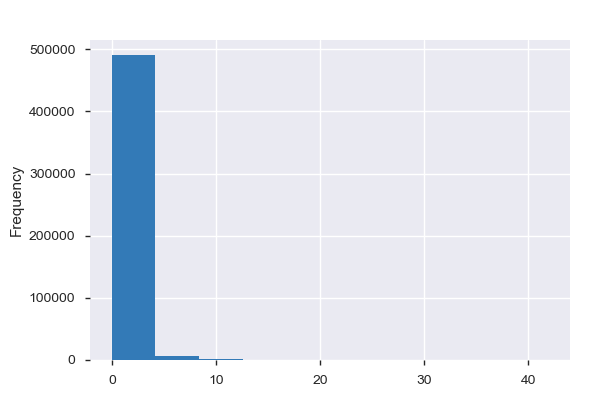

**Common Values**

| Value | Count | Frequency (%) |  |
| --- | --- | --- | --- |
| 0.5 | 84957 | 17.0% |  |
| 0.3 | 61694 | 12.3% |  |
| 0.4 | 52828 | 10.6% |  |
| 0.6 | 44205 | 8.8% |  |
| 1.6 | 39760 | 8.0% |  |
| 0.7 | 38168 | 7.6% |  |
| 0.8 | 30893 | 6.2% |  |
| 0.9 | 21420 | 4.3% |  |
| 0.2 | 20884 | 4.2% |  |
| 0.0 | 19929 | 4.0% |  |
| Other values (203) | 85262 | 17.1% |  |

**Extreme Values**

Minimum 5 values

| Value | Count | Frequency (%) |  |
| --- | --- | --- | --- |
| 0.0 | 19929 | 4.0% |  |
| 0.1 | 4132 | 0.8% |  |
| 0.2 | 20884 | 4.2% |  |
| 0.3 | 61694 | 12.3% |  |
| 0.4 | 52828 | 10.6% |  |

Maximum 5 values

| Value | Count | Frequency (%) |  |
| --- | --- | --- | --- |
| 31.0 | 1 | 0.0% |  |
| 33.3 | 1 | 0.0% |  |
| 33.7 | 1 | 0.0% |  |
| 38.0 | 1 | 0.0% |  |
| 41.9 | 1 | 0.0% |  |

W_MILEAGE  
Numeric

| Distinct count | 89139 |
| --- | --- |
| Unique (%) | 17.8% |
| Missing (%) | 0.0% |
| Missing (n) | 0 |
| Infinite (%) | 0.0% |
| Infinite (n) | 0 |

| Mean | 31806 |
| --- | --- |
| Minimum | 0 |
| Maximum | 99999 |
| Zeros (%) | 2.0% |

Toggle details

**Statistics**

Quantile statistics

| Minimum | 0 |
| --- | --- |
| 5-th percentile | 8 |
| Q1 | 9250.8 |
| Median | 25170 |
| Q3 | 48164 |
| 95-th percentile | 90409 |
| Maximum | 99999 |
| Range | 99999 |
| Interquartile range | 38913 |

Descriptive statistics

| Standard deviation | 27394 |
| --- | --- |
| Coef of variation | 0.86127 |
| Kurtosis | -0.13369 |
| Mean | 31806 |
| MAD | 22396 |
| Skewness | 0.86161 |
| Sum | 15902909456 |
| Variance | 750410000 |
| Memory size | 3.8 MiB |

**Histogram**

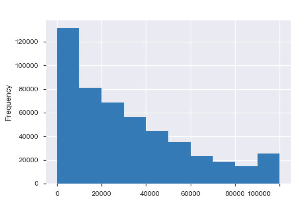

**Common Values**

| Value | Count | Frequency (%) |  |
| --- | --- | --- | --- |
| 99999 | 11877 | 2.4% |  |
| 0 | 9923 | 2.0% |  |
| 1 | 6880 | 1.4% |  |
| 5 | 4715 | 0.9% |  |
| 10 | 1712 | 0.3% |  |
| 8 | 919 | 0.2% |  |
| 4 | 793 | 0.2% |  |
| 6 | 660 | 0.1% |  |
| 3 | 641 | 0.1% |  |
| 12 | 414 | 0.1% |  |
| Other values (89129) | 461466 | 92.3% |  |

**Extreme Values**

Minimum 5 values

| Value | Count | Frequency (%) |  |
| --- | --- | --- | --- |
| 0 | 9923 | 2.0% |  |
| 1 | 6880 | 1.4% |  |
| 2 | 362 | 0.1% |  |
| 3 | 641 | 0.1% |  |
| 4 | 793 | 0.2% |  |

Maximum 5 values

| Value | Count | Frequency (%) |  |
| --- | --- | --- | --- |
| 99995 | 13 | 0.0% |  |
| 99996 | 4 | 0.0% |  |
| 99997 | 7 | 0.0% |  |
| 99998 | 31 | 0.0% |  |
| 99999 | 11877 | 2.4% |  |

W_MILEAGE_DIV  
Categorical

| Distinct count | 2 |
| --- | --- |
| Unique (%) | 0.0% |
| Missing (%) | 0.0% |
| Missing (n) | 0 |

| K | 493902 |
| --- | --- |
| H | 6098 |

Toggle details

| Value | Count | Frequency (%) |  |
| --- | --- | --- | --- |
| K | 493902 | 98.8% |  |
| H | 6098 | 1.2% |  |

W_MINUS_DIV  
Boolean

| Distinct count | 2 |
| --- | --- |
| Unique (%) | 0.0% |
| Missing (%) | 0.0% |
| Missing (n) | 0 |

| Mean | 0.99945 |
| --- | --- |

| 1 | 499862 |
| --- | --- |
| -1 | 138 |

Toggle details

| Value | Count | Frequency (%) |  |
| --- | --- | --- | --- |
| 1 | 499862 | 100.0% |  |
| -1 | 138 | 0.0% |  |

W_OPERATION_CD  
Categorical

| Distinct count | 1988 |
| --- | --- |
| Unique (%) | 0.4% |
| Missing (%) | 43.0% |
| Missing (n) | 214917 |

| HA9999 | 37423 |
| --- | --- |
| GH9999 | 31779 |
| SN9999 | 28261 |
| Other values (1984) | 187620 |
| (Missing) | 214917 |

Toggle details

| Value | Count | Frequency (%) |  |
| --- | --- | --- | --- |
| HA9999 | 37423 | 7.5% |  |
| GH9999 | 31779 | 6.4% |  |
| SN9999 | 28261 | 5.7% |  |
| MA9999 | 23659 | 4.7% |  |
| QD78R0 | 17873 | 3.6% |  |
| HM9999 | 11076 | 2.2% |  |
| DH9999 | 7115 | 1.4% |  |
| DA9999 | 6518 | 1.3% |  |
| CB9999 | 6186 | 1.2% |  |
| FB9999 | 5852 | 1.2% |  |
| Other values (1977) | 109341 | 21.9% |  |
| (Missing) | 214917 | 43.0% |  |

W_PARTS_AMT  
Numeric

| Distinct count | 28850 |
| --- | --- |
| Unique (%) | 5.8% |
| Missing (%) | 0.0% |
| Missing (n) | 0 |
| Infinite (%) | 0.0% |
| Infinite (n) | 0 |

| Mean | 8610.1 |
| --- | --- |
| Minimum | -191918 |
| Maximum | 656692 |
| Zeros (%) | 21.8% |

Toggle details

**Statistics**

Quantile statistics

| Minimum | -191918 |
| --- | --- |
| 5-th percentile | 0 |
| Q1 | 134 |
| Median | 1972 |
| Q3 | 9000 |
| 95-th percentile | 33904 |
| Maximum | 656692 |
| Range | 848610 |
| Interquartile range | 8866 |

Descriptive statistics

| Standard deviation | 20653 |
| --- | --- |
| Coef of variation | 2.3987 |
| Kurtosis | 87.197 |
| Mean | 8610.1 |
| MAD | 10289 |
| Skewness | 7.6094 |
| Sum | 4305039764 |
| Variance | 426560000 |
| Memory size | 3.8 MiB |

**Histogram**

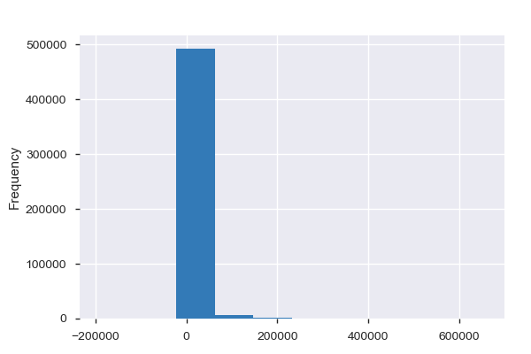

**Common Values**

| Value | Count | Frequency (%) |  |
| --- | --- | --- | --- |
| 0 | 108944 | 21.8% |  |
| 1908 | 16028 | 3.2% |  |
| 3444 | 8125 | 1.6% |  |
| 685 | 5341 | 1.1% |  |
| 4122 | 5113 | 1.0% |  |
| 3119 | 4912 | 1.0% |  |
| 702 | 4766 | 1.0% |  |
| 15145 | 4600 | 0.9% |  |
| 1581 | 4298 | 0.9% |  |
| 3475 | 3959 | 0.8% |  |
| Other values (28840) | 333914 | 66.8% |  |

**Extreme Values**

Minimum 5 values

| Value | Count | Frequency (%) |  |
| --- | --- | --- | --- |
| -191918 | 1 | 0.0% |  |
| -148607 | 1 | 0.0% |  |
| -128004 | 1 | 0.0% |  |
| -92820 | 1 | 0.0% |  |
| -81167 | 1 | 0.0% |  |

Maximum 5 values

| Value | Count | Frequency (%) |  |
| --- | --- | --- | --- |
| 489179 | 1 | 0.0% |  |
| 498922 | 1 | 0.0% |  |
| 500390 | 1 | 0.0% |  |
| 526035 | 1 | 0.0% |  |
| 656692 | 1 | 0.0% |  |

W_PROCESS_MONTH  
Numeric

| Distinct count | 9 |
| --- | --- |
| Unique (%) | 0.0% |
| Missing (%) | 0.0% |
| Missing (n) | 0 |
| Infinite (%) | 0.0% |
| Infinite (n) | 0 |

| Mean | 201500 |
| --- | --- |
| Minimum | 201501 |
| Maximum | 201511 |
| Zeros (%) | 0.0% |

Toggle details

**Statistics**

Quantile statistics

| Minimum | 201501 |
| --- | --- |
| 5-th percentile | 201500 |
| Q1 | 201500 |
| Median | 201500 |
| Q3 | 201510 |
| 95-th percentile | 201510 |
| Maximum | 201511 |
| Range | 10 |
| Interquartile range | 4 |

Descriptive statistics

| Standard deviation | 2.4355 |
| --- | --- |
| Coef of variation | 1.2087e-05 |
| Kurtosis | 0.55499 |
| Mean | 201500 |
| MAD | 1.9596 |
| Skewness | 0.83968 |
| Sum | 100752155455 |
| Variance | 5.9316 |
| Memory size | 3.8 MiB |

**Histogram**

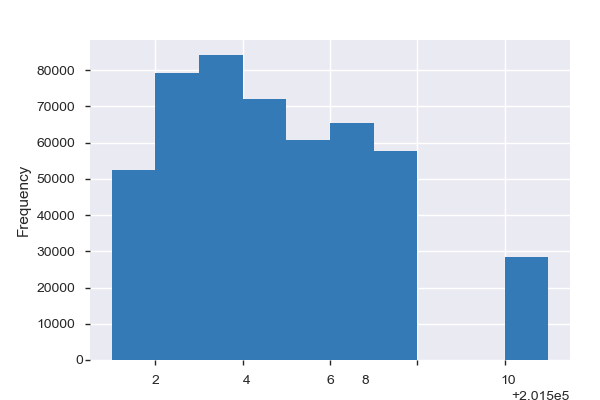

**Common Values**

| Value | Count | Frequency (%) |  |
| --- | --- | --- | --- |
| 201503 | 84094 | 16.8% |  |
| 201502 | 79307 | 15.9% |  |
| 201504 | 71940 | 14.4% |  |
| 201506 | 65426 | 13.1% |  |
| 201505 | 60758 | 12.2% |  |
| 201507 | 57567 | 11.5% |  |
| 201501 | 52559 | 10.5% |  |
| 201511 | 21435 | 4.3% |  |
| 201510 | 6914 | 1.4% |  |

**Extreme Values**

Minimum 5 values

| Value | Count | Frequency (%) |  |
| --- | --- | --- | --- |
| 201501 | 52559 | 10.5% |  |
| 201502 | 79307 | 15.9% |  |
| 201503 | 84094 | 16.8% |  |
| 201504 | 71940 | 14.4% |  |
| 201505 | 60758 | 12.2% |  |

Maximum 5 values

| Value | Count | Frequency (%) |  |
| --- | --- | --- | --- |
| 201505 | 60758 | 12.2% |  |
| 201506 | 65426 | 13.1% |  |
| 201507 | 57567 | 11.5% |  |
| 201510 | 6914 | 1.4% |  |
| 201511 | 21435 | 4.3% |  |

W_PROD_BASE_CD  
Numeric

| Distinct count | 20 |
| --- | --- |
| Unique (%) | 0.0% |
| Missing (%) | 0.0% |
| Missing (n) | 0 |
| Infinite (%) | 0.0% |
| Infinite (n) | 0 |

| Mean | 120390 |
| --- | --- |
| Minimum | 100010 |
| Maximum | 410010 |
| Zeros (%) | 0.0% |

Toggle details

**Statistics**

Quantile statistics

| Minimum | 100010 |
| --- | --- |
| 5-th percentile | 100100 |
| Q1 | 100100 |
| Median | 100100 |
| Q3 | 100100 |
| 95-th percentile | 227510 |
| Maximum | 410010 |
| Range | 310000 |
| Interquartile range | 0 |

Descriptive statistics

| Standard deviation | 48699 |
| --- | --- |
| Coef of variation | 0.40451 |
| Kurtosis | 5.8406 |
| Mean | 120390 |
| MAD | 33328 |
| Skewness | 2.4262 |
| Sum | 60194740113 |
| Variance | 2371600000 |
| Memory size | 3.8 MiB |

**Histogram**

[figure not shown]

**Common Values**

| Value | Count | Frequency (%) |  |
| --- | --- | --- | --- |
| 100100 | 397528 | 79.5% |  |
| 227510 | 68620 | 13.7% |  |
| 111700 | 13781 | 2.8% |  |
| 111010 | 6402 | 1.3% |  |
| 118700 | 2131 | 0.4% |  |
| 105531 | 2093 | 0.4% |  |
| 304050 | 1670 | 0.3% |  |
| 410010 | 1664 | 0.3% |  |
| 124510 | 1482 | 0.3% |  |
| 100200 | 873 | 0.2% |  |
| Other values (10) | 3756 | 0.8% |  |

**Extreme Values**

Minimum 5 values

| Value | Count | Frequency (%) |  |
| --- | --- | --- | --- |
| 100010 | 14 | 0.0% |  |
| 100100 | 397528 | 79.5% |  |
| 100200 | 873 | 0.2% |  |
| 105370 | 620 | 0.1% |  |
| 105470 | 687 | 0.1% |  |

Maximum 5 values

| Value | Count | Frequency (%) |  |
| --- | --- | --- | --- |
| 227510 | 68620 | 13.7% |  |
| 302500 | 82 | 0.0% |  |
| 304050 | 1670 | 0.3% |  |
| 401020 | 320 | 0.1% |  |
| 410010 | 1664 | 0.3% |  |

W_PROD_DIV  
Categorical

| Distinct count | 5 |
| --- | --- |
| Unique (%) | 0.0% |
| Missing (%) | 0.0% |
| Missing (n) | 0 |

| B | 429770 |
| --- | --- |
| A | 64079 |
| C | 5542 |
| Other values (2) | 609 |

Toggle details

| Value | Count | Frequency (%) |  |
| --- | --- | --- | --- |
| B | 429770 | 86.0% |  |
| A | 64079 | 12.8% |  |
| C | 5542 | 1.1% |  |
| F | 556 | 0.1% |  |
| G | 53 | 0.0% |  |

W_PROD_MODEL_CD  
Categorical

| Distinct count | 4040 |
| --- | --- |
| Unique (%) | 0.8% |
| Missing (%) | 0.1% |
| Missing (n) | 422 |

| YP7C1 | 21561 |
| --- | --- |
| YS124 | 15201 |
| YP7B1 | 9332 |
| Other values (4036) | 453484 |

Toggle details

| Value | Count | Frequency (%) |  |
| --- | --- | --- | --- |
| YP7C1 | 21561 | 4.3% |  |
| YS124 | 15201 | 3.0% |  |
| YP7B1 | 9332 | 1.9% |  |
| YW121 | 9192 | 1.8% |  |
| YY375 | 8593 | 1.7% |  |
| YT211B7J | 8521 | 1.7% |  |
| YS123 | 8444 | 1.7% |  |
| YP5C1 | 8407 | 1.7% |  |
| YP6B3 | 8270 | 1.7% |  |
| YAA11 | 8261 | 1.7% |  |
| Other values (4029) | 393796 | 78.8% |  |

W_SALES_DATE  
Numeric

| Distinct count | 5422 |
| --- | --- |
| Unique (%) | 1.1% |
| Missing (%) | 0.0% |
| Missing (n) | 0 |
| Infinite (%) | 0.0% |
| Infinite (n) | 0 |

| Mean | 20111000 |
| --- | --- |
| Minimum | 19880324 |
| Maximum | 20151119 |
| Zeros (%) | 0.0% |

Toggle details

**Statistics**

Quantile statistics

| Minimum | 19880324 |
| --- | --- |
| 5-th percentile | 20040000 |
| Q1 | 20091000 |
| Median | 20120000 |
| Q3 | 20131000 |
| 95-th percentile | 20150000 |
| Maximum | 20151119 |
| Range | 270795 |
| Interquartile range | 40005 |

Descriptive statistics

| Standard deviation | 31567 |
| --- | --- |
| Coef of variation | 0.0015696 |
| Kurtosis | 0.78342 |
| Mean | 20111000 |
| MAD | 24870 |
| Skewness | -1.0671 |
| Sum | 10055411564043 |
| Variance | 996460000 |
| Memory size | 3.8 MiB |

**Histogram**

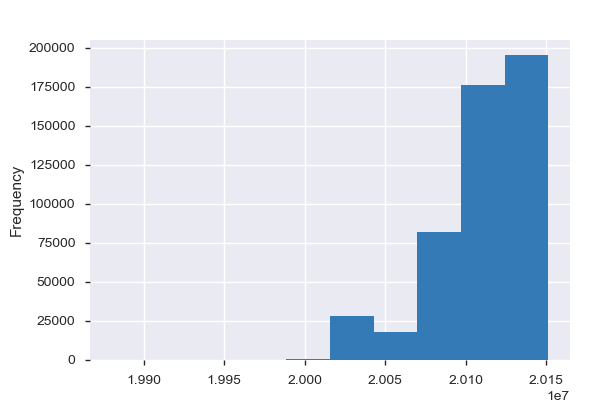

**Common Values**

| Value | Count | Frequency (%) |  |
| --- | --- | --- | --- |
| 20130930 | 1433 | 0.3% |  |
| 20120229 | 1329 | 0.3% |  |
| 20120330 | 1310 | 0.3% |  |
| 20120531 | 1267 | 0.3% |  |
| 20120629 | 1258 | 0.3% |  |
| 20110131 | 1257 | 0.3% |  |
| 20100630 | 1181 | 0.2% |  |
| 20130628 | 1173 | 0.2% |  |
| 20150401 | 1149 | 0.2% |  |
| 20140331 | 1125 | 0.2% |  |
| Other values (5412) | 487518 | 97.5% |  |

**Extreme Values**

Minimum 5 values

| Value | Count | Frequency (%) |  |
| --- | --- | --- | --- |
| 19880324 | 1 | 0.0% |  |
| 19890727 | 1 | 0.0% |  |
| 19890930 | 1 | 0.0% |  |
| 19900210 | 1 | 0.0% |  |
| 19900217 | 1 | 0.0% |  |

Maximum 5 values

| Value | Count | Frequency (%) |  |
| --- | --- | --- | --- |
| 20151115 | 1 | 0.0% |  |
| 20151116 | 5 | 0.0% |  |
| 20151117 | 2 | 0.0% |  |
| 20151118 | 5 | 0.0% |  |
| 20151119 | 5 | 0.0% |  |

W_SALES_TO_FAILURE  
Numeric

| Distinct count | 239 |
| --- | --- |
| Unique (%) | 0.0% |
| Missing (%) | 0.0% |
| Missing (n) | 0 |
| Infinite (%) | 0.0% |
| Infinite (n) | 0 |

| Mean | 45.488 |
| --- | --- |
| Minimum | 0 |
| Maximum | 999 |
| Zeros (%) | 4.5% |

Toggle details

**Statistics**

Quantile statistics

| Minimum | 0 |
| --- | --- |
| 5-th percentile | 1 |
| Q1 | 16 |
| Median | 36 |
| Q3 | 64 |
| 95-th percentile | 134 |
| Maximum | 999 |
| Range | 999 |
| Interquartile range | 48 |

Descriptive statistics

| Standard deviation | 37.934 |
| --- | --- |
| Coef of variation | 0.83394 |
| Kurtosis | 11.692 |
| Mean | 45.488 |
| MAD | 29.955 |
| Skewness | 1.4695 |
| Sum | 22744032 |
| Variance | 1439 |
| Memory size | 3.8 MiB |

**Histogram**

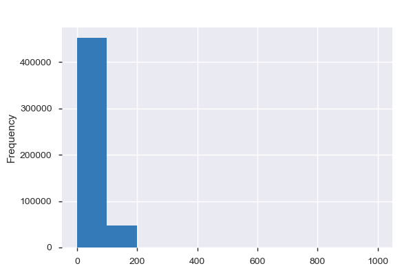

**Common Values**

| Value | Count | Frequency (%) |  |
| --- | --- | --- | --- |
| 36 | 25800 | 5.2% |  |
| 0 | 22441 | 4.5% |  |
| 60 | 11124 | 2.2% |  |
| 24 | 9989 | 2.0% |  |
| 12 | 9823 | 2.0% |  |
| 1 | 9283 | 1.9% |  |
| 13 | 8927 | 1.8% |  |
| 25 | 7583 | 1.5% |  |
| 2 | 7431 | 1.5% |  |
| 14 | 7263 | 1.5% |  |
| Other values (229) | 380336 | 76.1% |  |

**Extreme Values**

Minimum 5 values

| Value | Count | Frequency (%) |  |
| --- | --- | --- | --- |
| 0 | 22441 | 4.5% |  |
| 1 | 9283 | 1.9% |  |
| 2 | 7431 | 1.5% |  |
| 3 | 6611 | 1.3% |  |
| 4 | 5402 | 1.1% |  |

Maximum 5 values

| Value | Count | Frequency (%) |  |
| --- | --- | --- | --- |
| 266 | 1 | 0.0% |  |
| 268 | 1 | 0.0% |  |
| 285 | 1 | 0.0% |  |
| 323 | 1 | 0.0% |  |
| 999 | 14 | 0.0% |  |

W_SB_NO  
Constant

*This variable is constant and should be ignored for analysis*

| Constant value |  |
| --- | --- |

W_SHIPPING_AMT  
Numeric

| Distinct count | 9332 |
| --- | --- |
| Unique (%) | 1.9% |
| Missing (%) | 0.0% |
| Missing (n) | 0 |
| Infinite (%) | 0.0% |
| Infinite (n) | 0 |

| Mean | 2055.9 |
| --- | --- |
| Minimum | 0 |
| Maximum | 763620 |
| Zeros (%) | 51.3% |

Toggle details

**Statistics**

Quantile statistics

| Minimum | 0 |
| --- | --- |
| 5-th percentile | 0 |
| Q1 | 0 |
| Median | 0 |
| Q3 | 722 |
| 95-th percentile | 13215 |
| Maximum | 763620 |
| Range | 763620 |
| Interquartile range | 722 |

Descriptive statistics

| Standard deviation | 8491.1 |
| --- | --- |
| Coef of variation | 4.1301 |
| Kurtosis | 1168.2 |
| Mean | 2055.9 |
| MAD | 3070.2 |
| Skewness | 23.792 |
| Sum | 1027957682 |
| Variance | 72099000 |
| Memory size | 3.8 MiB |

**Histogram**

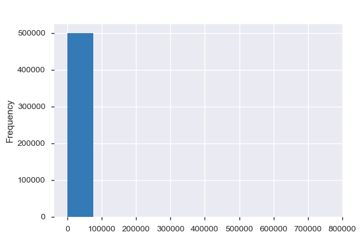

**Common Values**

| Value | Count | Frequency (%) |  |
| --- | --- | --- | --- |
| 0 | 256648 | 51.3% |  |
| 571 | 16022 | 3.2% |  |
| 3753 | 8121 | 1.6% |  |
| 4492 | 5078 | 1.0% |  |
| 219 | 4794 | 1.0% |  |
| 141 | 4351 | 0.9% |  |
| 11 | 3972 | 0.8% |  |
| 2682 | 3797 | 0.8% |  |
| 3718 | 3306 | 0.7% |  |
| 225 | 3117 | 0.6% |  |
| Other values (9322) | 190794 | 38.2% |  |

**Extreme Values**

Minimum 5 values

| Value | Count | Frequency (%) |  |
| --- | --- | --- | --- |
| 0 | 256648 | 51.3% |  |
| 1 | 95 | 0.0% |  |
| 2 | 5 | 0.0% |  |
| 3 | 1008 | 0.2% |  |
| 4 | 128 | 0.0% |  |

Maximum 5 values

| Value | Count | Frequency (%) |  |
| --- | --- | --- | --- |
| 399750 | 2 | 0.0% |  |
| 416894 | 1 | 0.0% |  |
| 595884 | 1 | 0.0% |  |
| 648298 | 1 | 0.0% |  |
| 763620 | 4 | 0.0% |  |

W_SHOP_CD  
Numeric

| Distinct count | 147 |
| --- | --- |
| Unique (%) | 0.0% |
| Missing (%) | 57.3% |
| Missing (n) | 286728 |
| Infinite (%) | 0.0% |
| Infinite (n) | 0 |

| Mean | 34.862 |
| --- | --- |
| Minimum | 1 |
| Maximum | 938 |
| Zeros (%) | 0.0% |

Toggle details

**Statistics**

Quantile statistics

| Minimum | 1 |
| --- | --- |
| 5-th percentile | 2 |
| Q1 | 11 |
| Median | 25 |
| Q3 | 45 |
| 95-th percentile | 81 |
| Maximum | 938 |
| Range | 937 |
| Interquartile range | 34 |

Descriptive statistics

| Standard deviation | 46.115 |
| --- | --- |
| Coef of variation | 1.3228 |
| Kurtosis | 82.592 |
| Mean | 34.862 |
| MAD | 24.073 |
| Skewness | 7.2811 |
| Sum | 7435100 |
| Variance | 2126.6 |
| Memory size | 3.8 MiB |

**Histogram**

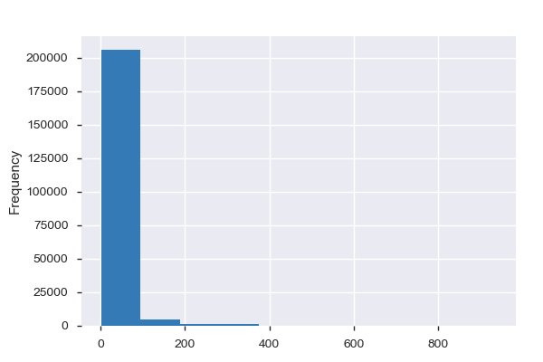

**Common Values**

| Value | Count | Frequency (%) |  |
| --- | --- | --- | --- |
| 10.0 | 11835 | 2.4% |  |
| 20.0 | 10079 | 2.0% |  |
| 1.0 | 9056 | 1.8% |  |
| 30.0 | 8884 | 1.8% |  |
| 50.0 | 6213 | 1.2% |  |
| 3.0 | 6013 | 1.2% |  |
| 35.0 | 5410 | 1.1% |  |
| 21.0 | 5175 | 1.0% |  |
| 2.0 | 5140 | 1.0% |  |
| 60.0 | 4786 | 1.0% |  |
| Other values (136) | 140681 | 28.1% |  |
| (Missing) | 286728 | 57.3% |  |

**Extreme Values**

Minimum 5 values

| Value | Count | Frequency (%) |  |
| --- | --- | --- | --- |
| 1.0 | 9056 | 1.8% |  |
| 2.0 | 5140 | 1.0% |  |
| 3.0 | 6013 | 1.2% |  |
| 4.0 | 4098 | 0.8% |  |
| 5.0 | 3521 | 0.7% |  |

Maximum 5 values

| Value | Count | Frequency (%) |  |
| --- | --- | --- | --- |
| 700.0 | 63 | 0.0% |  |
| 720.0 | 54 | 0.0% |  |
| 730.0 | 98 | 0.0% |  |
| 926.0 | 1 | 0.0% |  |
| 938.0 | 1 | 0.0% |  |

W_SHOP_DIV  
Numeric

| Distinct count | 5 |
| --- | --- |
| Unique (%) | 0.0% |
| Missing (%) | 0.0% |
| Missing (n) | 0 |
| Infinite (%) | 0.0% |
| Infinite (n) | 0 |

| Mean | 1.2409 |
| --- | --- |
| Minimum | 0 |
| Maximum | 4 |
| Zeros (%) | 0.1% |

Toggle details

**Statistics**

Quantile statistics

| Minimum | 0 |
| --- | --- |
| 5-th percentile | 1 |
| Q1 | 1 |
| Median | 1 |
| Q3 | 1 |
| 95-th percentile | 3 |
| Maximum | 4 |
| Range | 4 |
| Interquartile range | 0 |

Descriptive statistics

| Standard deviation | 0.65492 |
| --- | --- |
| Coef of variation | 0.52778 |
| Kurtosis | 3.5636 |
| Mean | 1.2409 |
| MAD | 0.42518 |
| Skewness | 2.3407 |
| Sum | 620445 |
| Variance | 0.42892 |
| Memory size | 3.8 MiB |

**Histogram**

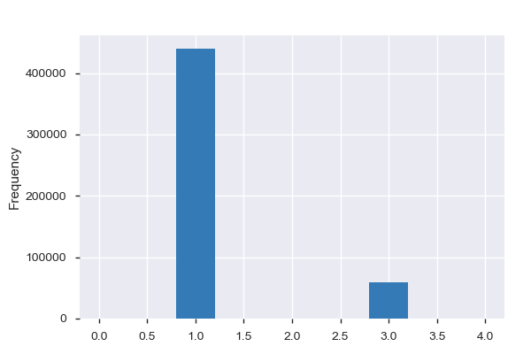

**Common Values**

| Value | Count | Frequency (%) |  |
| --- | --- | --- | --- |
| 1 | 439530 | 87.9% |  |
| 3 | 59575 | 11.9% |  |
| 4 | 535 | 0.1% |  |
| 0 | 335 | 0.1% |  |
| 2 | 25 | 0.0% |  |

**Extreme Values**

Minimum 5 values

| Value | Count | Frequency (%) |  |
| --- | --- | --- | --- |
| 0 | 335 | 0.1% |  |
| 1 | 439530 | 87.9% |  |
| 2 | 25 | 0.0% |  |
| 3 | 59575 | 11.9% |  |
| 4 | 535 | 0.1% |  |

Maximum 5 values

| Value | Count | Frequency (%) |  |
| --- | --- | --- | --- |
| 0 | 335 | 0.1% |  |
| 1 | 439530 | 87.9% |  |
| 2 | 25 | 0.0% |  |
| 3 | 59575 | 11.9% |  |
| 4 | 535 | 0.1% |  |

W_SRC_DIV  
Constant

*This variable is constant and should be ignored for analysis*

| Constant value | 1 |
| --- | --- |

W_SRC_KEY  
Categorical, Unique

| First 3 values |
| --- |
| 201502006695801 |
| 2015051945BB6010834 |
| 2015033780B15010001 |

| Last 3 values |
| --- |
| 201511007004859 |
| 201503006751675 |
| 201502006689425 |

Toggle details

First 10 values

| Value | Count | Frequency (%) |  |
| --- | --- | --- | --- |
| 201501002741786 | 1 | 0.0% |  |
| 201501002865145 | 1 | 0.0% |  |
| 201501002885223 | 1 | 0.0% |  |
| 201501002888069 | 1 | 0.0% |  |
| 201501002889294 | 1 | 0.0% |  |

Last 10 values

| Value | Count | Frequency (%) |  |
| --- | --- | --- | --- |
| 2015116156A1509003 | 1 | 0.0% |  |
| 2015116156A1509005 | 1 | 0.0% |  |
| 2015116156A1509007 | 1 | 0.0% |  |
| 2015116156A1509008 | 1 | 0.0% |  |
| 2015116156A1509009 | 1 | 0.0% |  |

W_SUBLET_AMT  
Numeric

| Distinct count | 3672 |
| --- | --- |
| Unique (%) | 0.7% |
| Missing (%) | 0.0% |
| Missing (n) | 0 |
| Infinite (%) | 0.0% |
| Infinite (n) | 0 |

| Mean | 575.6 |
| --- | --- |
| Minimum | -201331 |
| Maximum | 716239 |
| Zeros (%) | 93.2% |

Toggle details

**Statistics**

Quantile statistics

| Minimum | -201331 |
| --- | --- |
| 5-th percentile | 0 |
| Q1 | 0 |
| Median | 0 |
| Q3 | 0 |
| 95-th percentile | 741 |
| Maximum | 716239 |
| Range | 917570 |
| Interquartile range | 0 |

Descriptive statistics

| Standard deviation | 7106.2 |
| --- | --- |
| Coef of variation | 12.346 |
| Kurtosis | 2630.4 |
| Mean | 575.6 |
| MAD | 1079.3 |
| Skewness | 39.97 |
| Sum | 287800907 |
| Variance | 50498000 |
| Memory size | 3.8 MiB |

**Histogram**

[figure not shown]

**Common Values**

| Value | Count | Frequency (%) |  |
| --- | --- | --- | --- |
| 0 | 466134 | 93.2% |  |
| 1005 | 8651 | 1.7% |  |
| 873 | 3776 | 0.8% |  |
| 741 | 1941 | 0.4% |  |
| 3174 | 1185 | 0.2% |  |
| 663 | 1062 | 0.2% |  |
| 299 | 952 | 0.2% |  |
| 439 | 665 | 0.1% |  |
| 550 | 640 | 0.1% |  |
| 474 | 612 | 0.1% |  |
| Other values (3662) | 14382 | 2.9% |  |

**Extreme Values**

Minimum 5 values

| Value | Count | Frequency (%) |  |
| --- | --- | --- | --- |
| -201331 | 1 | 0.0% |  |
| -85200 | 1 | 0.0% |  |
| -71750 | 1 | 0.0% |  |
| -52000 | 1 | 0.0% |  |
| -46740 | 1 | 0.0% |  |

Maximum 5 values

| Value | Count | Frequency (%) |  |
| --- | --- | --- | --- |
| 628241 | 1 | 0.0% |  |
| 653018 | 1 | 0.0% |  |
| 691942 | 1 | 0.0% |  |
| 697107 | 1 | 0.0% |  |
| 716239 | 1 | 0.0% |  |

W_SUBLET_HOUR  
Constant

*This variable is constant and should be ignored for analysis*

| Constant value | 0 |
| --- | --- |

W_TOTAL_AMT  
Highly correlated

*This variable is highly correlated with `W_PARTS_AMT` and should be ignored for analysis*

| Correlation | 0.90031 |
| --- | --- |

W_TROUBLE_CC  
Numeric

| Distinct count | 37 |
| --- | --- |
| Unique (%) | 0.0% |
| Missing (%) | 57.1% |
| Missing (n) | 285618 |
| Infinite (%) | 0.0% |
| Infinite (n) | 0 |

| Mean | 73.397 |
| --- | --- |
| Minimum | 11 |
| Maximum | 99 |
| Zeros (%) | 0.0% |

Toggle details

**Statistics**

Quantile statistics

| Minimum | 11 |
| --- | --- |
| 5-th percentile | 15 |
| Q1 | 42 |
| Median | 99 |
| Q3 | 99 |
| 95-th percentile | 99 |
| Maximum | 99 |
| Range | 88 |
| Interquartile range | 57 |

Descriptive statistics

| Standard deviation | 32.582 |
| --- | --- |
| Coef of variation | 0.44392 |
| Kurtosis | -1.3376 |
| Mean | 73.397 |
| MAD | 30.65 |
| Skewness | -0.63196 |
| Sum | 15735000 |
| Variance | 1061.6 |
| Memory size | 3.8 MiB |

**Histogram**

[figure not shown]

**Common Values**

| Value | Count | Frequency (%) |  |
| --- | --- | --- | --- |
| 99.0 | 128318 | 25.7% |  |
| 46.0 | 11588 | 2.3% |  |
| 32.0 | 8384 | 1.7% |  |
| 34.0 | 8103 | 1.6% |  |
| 31.0 | 6315 | 1.3% |  |
| 21.0 | 6232 | 1.2% |  |
| 42.0 | 5710 | 1.1% |  |
| 63.0 | 5640 | 1.1% |  |
| 13.0 | 5091 | 1.0% |  |
| 52.0 | 4860 | 1.0% |  |
| Other values (26) | 24141 | 4.8% |  |
| (Missing) | 285618 | 57.1% |  |

**Extreme Values**

Minimum 5 values

| Value | Count | Frequency (%) |  |
| --- | --- | --- | --- |
| 11.0 | 2069 | 0.4% |  |
| 12.0 | 2401 | 0.5% |  |
| 13.0 | 5091 | 1.0% |  |
| 14.0 | 938 | 0.2% |  |
| 15.0 | 434 | 0.1% |  |

Maximum 5 values

| Value | Count | Frequency (%) |  |
| --- | --- | --- | --- |
| 61.0 | 163 | 0.0% |  |
| 62.0 | 173 | 0.0% |  |
| 63.0 | 5640 | 1.1% |  |
| 64.0 | 83 | 0.0% |  |
| 99.0 | 128318 | 25.7% |  |

W_TROUBLE_CP  
Categorical

| Distinct count | 256 |
| --- | --- |
| Unique (%) | 0.1% |
| Missing (%) | 0.0% |
| Missing (n) | 0 |

| 99 | 214676 |
| --- | --- |
| 77 | 54271 |
| 84 | 37605 |
| Other values (253) | 193448 |

Toggle details

| Value | Count | Frequency (%) |  |
| --- | --- | --- | --- |
| 99 | 214676 | 42.9% |  |
| 77 | 54271 | 10.9% |  |
| 84 | 37605 | 7.5% |  |
| 74 | 21254 | 4.3% |  |
| 72 | 16223 | 3.2% |  |
| 83 | 10964 | 2.2% |  |
| 65 | 10483 | 2.1% |  |
| 99 | 9448 | 1.9% |  |
| 36 | 8227 | 1.6% |  |
| 88 | 7920 | 1.6% |  |
| Other values (246) | 108929 | 21.8% |  |

W_TROUBLE_DF  
Categorical

| Distinct count | 287 |
| --- | --- |
| Unique (%) | 0.1% |
| Missing (%) | 0.0% |
| Missing (n) | 0 |

| 29 | 77739 |
| --- | --- |
| VH | 37139 |
| VL | 35943 |
| Other values (284) | 349179 |

Toggle details

| Value | Count | Frequency (%) |  |
| --- | --- | --- | --- |
| 29 | 77739 | 15.5% |  |
| VH | 37139 | 7.4% |  |
| VL | 35943 | 7.2% |  |
| 99 | 24488 | 4.9% |  |
| TL | 23802 | 4.8% |  |
| WR | 23637 | 4.7% |  |
| 14 | 19436 | 3.9% |  |
| 15 | 17937 | 3.6% |  |
| VD | 17876 | 3.6% |  |
| 23 | 17099 | 3.4% |  |
| Other values (277) | 204904 | 41.0% |  |

W_TROUBLE_MP  
Numeric

| Distinct count | 10 |
| --- | --- |
| Unique (%) | 0.0% |
| Missing (%) | 57.1% |
| Missing (n) | 285618 |
| Infinite (%) | 0.0% |
| Infinite (n) | 0 |

| Mean | 6.1662 |
| --- | --- |
| Minimum | 1 |
| Maximum | 9 |
| Zeros (%) | 0.0% |

Toggle details

**Statistics**

Quantile statistics

| Minimum | 1 |
| --- | --- |
| 5-th percentile | 1 |
| Q1 | 5 |
| Median | 6 |
| Q3 | 9 |
| 95-th percentile | 9 |
| Maximum | 9 |
| Range | 8 |
| Interquartile range | 4 |

Descriptive statistics

| Standard deviation | 2.6489 |
| --- | --- |
| Coef of variation | 0.42959 |
| Kurtosis | -0.68694 |
| Mean | 6.1662 |
| MAD | 2.0892 |
| Skewness | -0.65648 |
| Sum | 1321900 |
| Variance | 7.0167 |
| Memory size | 3.8 MiB |

**Histogram**

[figure not shown]

**Common Values**

| Value | Count | Frequency (%) |  |
| --- | --- | --- | --- |
| 6.0 | 69743 | 13.9% |  |
| 9.0 | 63527 | 12.7% |  |
| 8.0 | 22551 | 4.5% |  |
| 1.0 | 22265 | 4.5% |  |
| 2.0 | 9972 | 2.0% |  |
| 3.0 | 9864 | 2.0% |  |
| 4.0 | 8936 | 1.8% |  |
| 5.0 | 4452 | 0.9% |  |
| 7.0 | 3072 | 0.6% |  |
| (Missing) | 285618 | 57.1% |  |

**Extreme Values**

Minimum 5 values

| Value | Count | Frequency (%) |  |
| --- | --- | --- | --- |
| 1.0 | 22265 | 4.5% |  |
| 2.0 | 9972 | 2.0% |  |
| 3.0 | 9864 | 2.0% |  |
| 4.0 | 8936 | 1.8% |  |
| 5.0 | 4452 | 0.9% |  |

Maximum 5 values

| Value | Count | Frequency (%) |  |
| --- | --- | --- | --- |
| 5.0 | 4452 | 0.9% |  |
| 6.0 | 69743 | 13.9% |  |
| 7.0 | 3072 | 0.6% |  |
| 8.0 | 22551 | 4.5% |  |
| 9.0 | 63527 | 12.7% |  |

W_VIN  
Categorical

| Distinct count | 433661 |
| --- | --- |
| Unique (%) | 86.7% |
| Missing (%) | 0.0% |
| Missing (n) | 0 |

| CF4MA-145043 | 23 |
| --- | --- |
| MR31S-801974 | 14 |
| MK32S-172464 | 12 |
| Other values (433658) | 499951 |

Toggle details

| Value | Count | Frequency (%) |  |
| --- | --- | --- | --- |
| CF4MA-145043 | 23 | 0.0% |  |
| MR31S-801974 | 14 | 0.0% |  |
| MK32S-172464 | 12 | 0.0% |  |
| JS3TE04V7E4103826 | 10 | 0.0% |  |
| MR31S-223069 | 10 | 0.0% |  |
| JS3TD04V1B4610431 | 10 | 0.0% |  |
| JSAJTAA4V00240754 | 9 | 0.0% |  |
| MR31S-802472 | 9 | 0.0% |  |
| MH34S-720388 | 9 | 0.0% |  |
| JS2YA21S2G6100786 | 9 | 0.0% |  |
| Other values (433651) | 499885 | 100.0% |  |

# Correlations

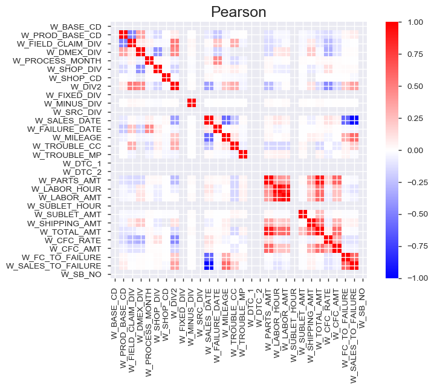

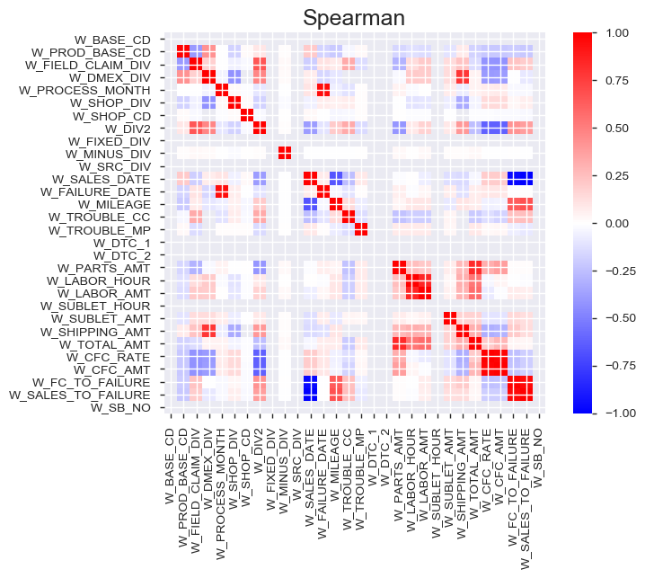

# Sample

|  | W_KEY | W_BASE_CD | W_PROD_BASE_CD | W_FIELD_CLAIM_DIV | W_PROD_DIV | W_DMEX_DIV | W_PROCESS_MONTH | W_DIST_CD | W_DIST_COUNTRY_CD | W_DIST_ISSUE_NO | W_SHOP_DIV | W_SHOP_CD | W_DIV1 | W_DIV2 | W_DIV3 | W_FIXED_DIV | W_MINUS_DIV | W_SRC_DIV | W_SRC_KEY | W_VIN | W_FCOK | W_PROD_MODEL_CD | W_SALES_DATE | W_FAILURE_DATE | W_MILEAGE_DIV | W_MILEAGE | W_CAUSAL_PART_NO | W_TROUBLE_CC | W_TROUBLE_CP | … |
| --- | --- | --- | --- | --- | --- | --- | --- | --- | --- | --- | --- | --- | --- | --- | --- | --- | --- | --- | --- | --- | --- | --- | --- | --- | --- | --- | --- | --- | --- | --- |
| 0 | WRJPJP201504B001202 | 100100 | 100100 | 1 | B | 0 | 201504 | 40223 | JP | 15C0100551 | 1 | 15.0 | 1 | 0 | NaN | 1 | 1 | 1 | 201504006777793 | MH34S-702672 | 20120901 | YV0E1B9J | 20120928 | 20150323 | K | 16283 | 72350-72M02 | 99.0 | 76 | … |
| 1 | WRJPJP201504B001203 | 100100 | 100100 | 1 | B | 0 | 201504 | 40223 | JP | 15C0105891 | 1 | 15.0 | 1 | 0 | NaN | 1 | 1 | 1 | 201504006776105 | MH34S-718306 | 20130101 | YV0E1B9J | 20130214 | 20150324 | K | 10433 | 72350-72M02 | 99.0 | 65 | … |
| 2 | WRJPJP201504B001204 | 100100 | 100100 | 1 | B | 0 | 201504 | 50224 | JP | 15D0054801 | 1 | 22.0 | 4 | 0 | NaN | 1 | 1 | 1 | 201504006791151 | MH23S-837237 | 20100101 | YG0B1B9D | 20100129 | 20150413 | K | 43200 | 17931-58J01 | 99.0 | 85 | … |
| 3 | WRJPJP201504B001205 | 100100 | 100100 | 1 | B | 0 | 201504 | 50224 | JP | 15C0085531 | 1 | 78.0 | 1 | 0 | NaN | 1 | 1 | 1 | 201504006770379 | MH23S-668540 | 20120401 | YG0A2B9D | 20120420 | 20150327 | K | 21877 | 17931-58J01 | 32.0 | 85 | … |
| 4 | WRJPJP201504B001206 | 100100 | 100100 | 1 | B | 0 | 201504 | 50224 | JP | 15C0057741 | 1 | 6.0 | 4 | 0 | NaN | 1 | 1 | 1 | 201504006772241 | MK21S-197951 | 20100401 | YT212B9F | 20100409 | 20150313 | K | 32461 | 17931-58J01 | 99.0 | 85 | … |